# Indel Signature InsDel5b

# InsDel5b

(corresponds to 83-type signature C_ID5)

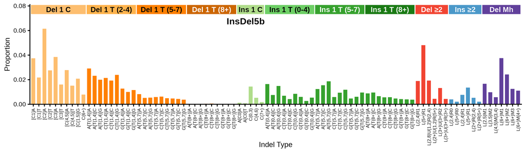

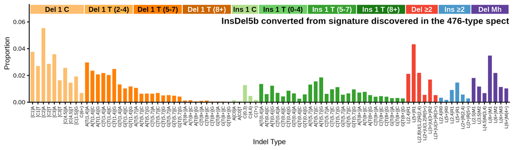

89-type spectrum of the linking tumor SP112290 | cosine similarity to InsDel5b: 0.9826

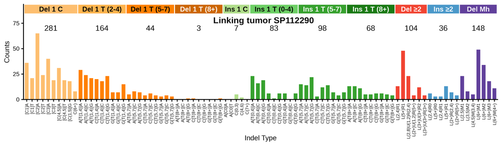

**Click to view decomposition of the linking tumor spectrum**

Partial mutation signature of SP112290 due to InsDel5b

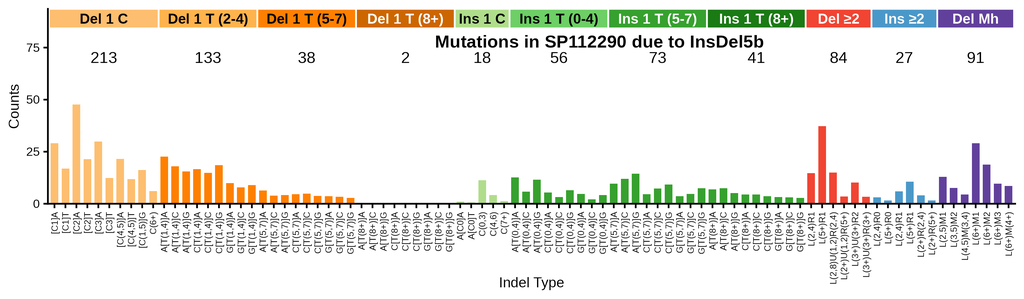

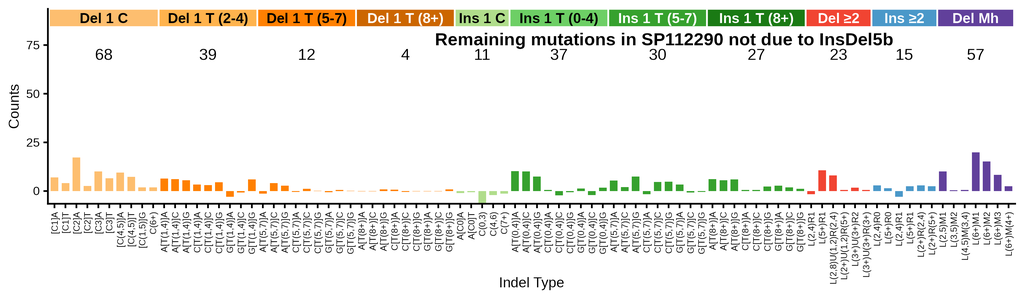

Max neg fraction (maximum allowed negative residual count as fraction of total): 0.03  
N subtract (mutation count assigned to signature): 775.7  
N residual (mutation count in residual “partial spectrum”): 260.3  
Total negative (sum of negative residual mutation counts): 31.1  
N negative channels (number of channels with negative residual): 24  
P(≥ total negative) (Monte Carlo estimated probability that negative-binomial-sampled spectra from the signature contributing N subtract mutations would produce a total negative count >= the observed Total negative; higher number means not surprising): 0.992

**Per-channel residual breakdown**

| Channel | Spectrum | Sig_Count | Residual | Sig_Prop |
| --- | --- | --- | --- | --- |
| [Del(C):R1]A | 36 | 29.0 | 7 | 0.03744 |
| [Del(C):R1]T | 21 | 16.9 | 4.1 | 0.02180 |
| [Del(C):R2]A | 65 | 47.7 | 17.3 | 0.06147 |
| [Del(C):R2]T | 24 | 21.4 | 2.6 | 0.02755 |
| [Del(C):R3]A | 40 | 29.9 | 10.1 | 0.03852 |
| [Del(C):R3]T | 19 | 12.4 | 6.6 | 0.01602 |
| [Del(C):R(4,5)]A | 31 | 21.5 | 9.5 | 0.02777 |
| [Del(C):R(4,5)]T | 19 | 11.8 | 7.2 | 0.01516 |
| [Del(C):R(1,5)]G | 18 | 16.2 | 1.8 | 0.02082 |
| Del(C):R(6,9) | 8 | 6.1 | 1.9 | 0.00784 |
| A[Del(T):R(1,4)]A | 29 | 22.6 | 6.4 | 0.02911 |
| A[Del(T):R(1,4)]C | 24 | 17.9 | 6.1 | 0.02312 |
| A[Del(T):R(1,4)]G | 21 | 15.5 | 5.5 | 0.01997 |
| C[Del(T):R(1,4)]A | 20 | 16.6 | 3.4 | 0.02139 |
| C[Del(T):R(1,4)]C | 18 | 14.9 | 3.1 | 0.01921 |
| C[Del(T):R(1,4)]G | 23 | 18.5 | 4.5 | 0.02387 |
| G[Del(T):R(1,4)]A | 7 | 9.9 | -2.9 | 0.01279 |
| G[Del(T):R(1,4)]C | 7 | 7.8 | -0.8 | 0.01007 |
| G[Del(T):R(1,4)]G | 15 | 8.9 | 6.1 | 0.01153 |
| A[Del(T):R(5,7)]A | 5 | 6.4 | -1.4 | 0.00821 |
| A[Del(T):R(5,7)]C | 8 | 4.0 | 4 | 0.00511 |
| A[Del(T):R(5,7)]G | 7 | 4.2 | 2.8 | 0.00540 |
| C[Del(T):R(5,7)]A | 4 | 4.5 | -0.5 | 0.00583 |
| C[Del(T):R(5,7)]C | 6 | 4.8 | 1.2 | 0.00619 |
| C[Del(T):R(5,7)]G | 4 | 3.8 | 0.2 | 0.00494 |
| G[Del(T):R(5,7)]A | 3 | 3.6 | -0.6 | 0.00470 |
| G[Del(T):R(5,7)]C | 4 | 3.4 | 0.6 | 0.00437 |
| G[Del(T):R(5,7)]G | 3 | 2.9 | 0.1 | 0.00370 |
| A[Del(T):R(8,)]A | 0 | 0.2 | -0.2 | 0.00025 |
| A[Del(T):R(8,)]C | 0 | 0.2 | -0.2 | 0.00027 |

[output cut: 59 more lines]

## 476-type representations corresponding to InsDel5b

Extracted 476-type signature corresponding to InsDel5b

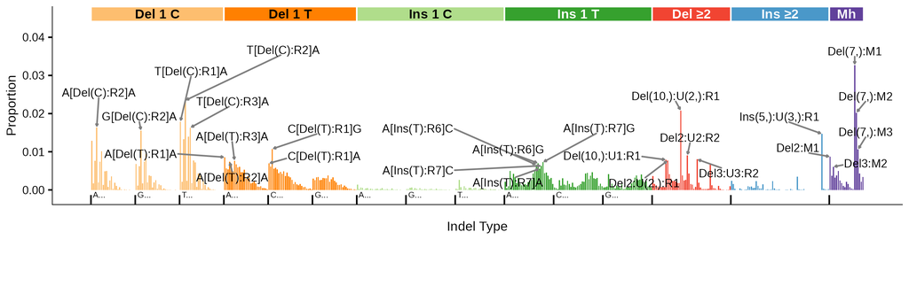

476-type spectrum of the linking tumor SP112290; cosine similarity to the extracted 476-type signature is 0.9445

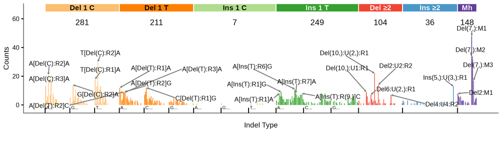

## 83-type signature corresponding to InsDel5b (C_ID5)

**Note**

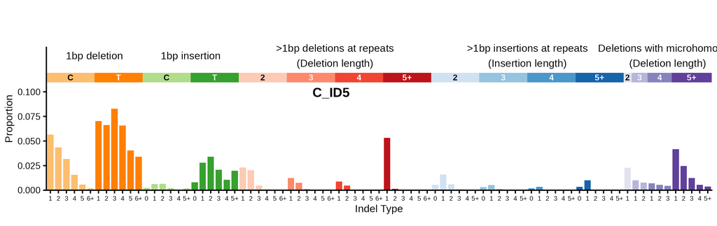

83-type signature converted from signature discovered in the 476-type spectra (using bipartite matching optimization) | cosine similarity to C_ID5: 0.7716

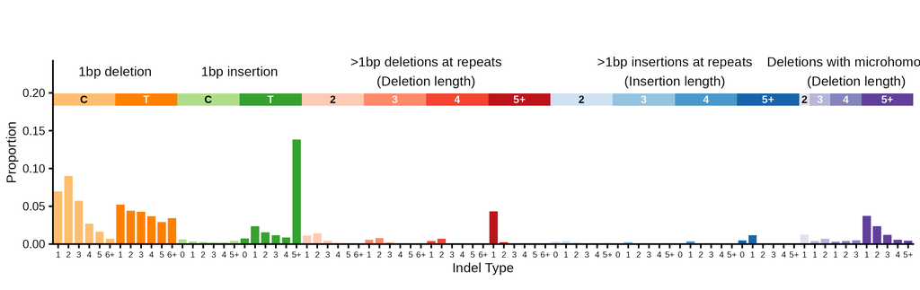

**Click to see flow diagrams: 476-type to 83-type collapse**

These Sankey diagrams show how the 476-type mutation categories are redistributed to 83-type categories using bipartite matching. We only show the diagrams for insertions or deletions of > 1 base because it is for these indels that 476-type categories map to > 1 83-type category.

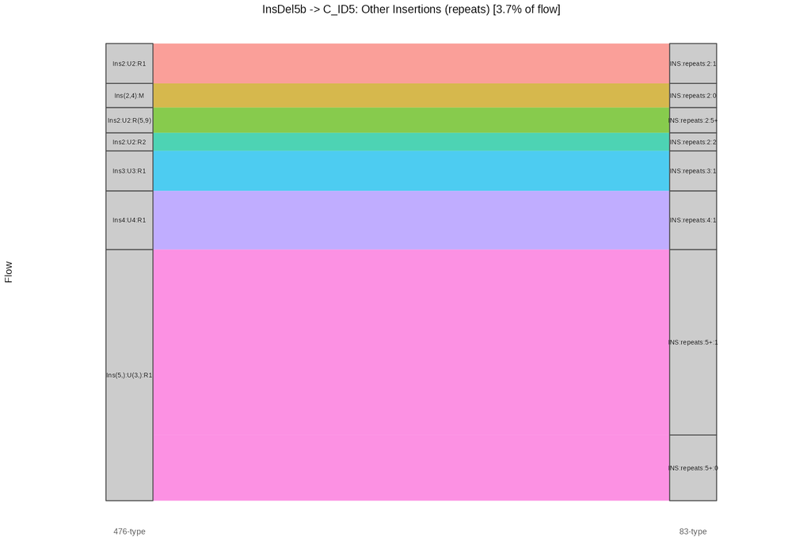

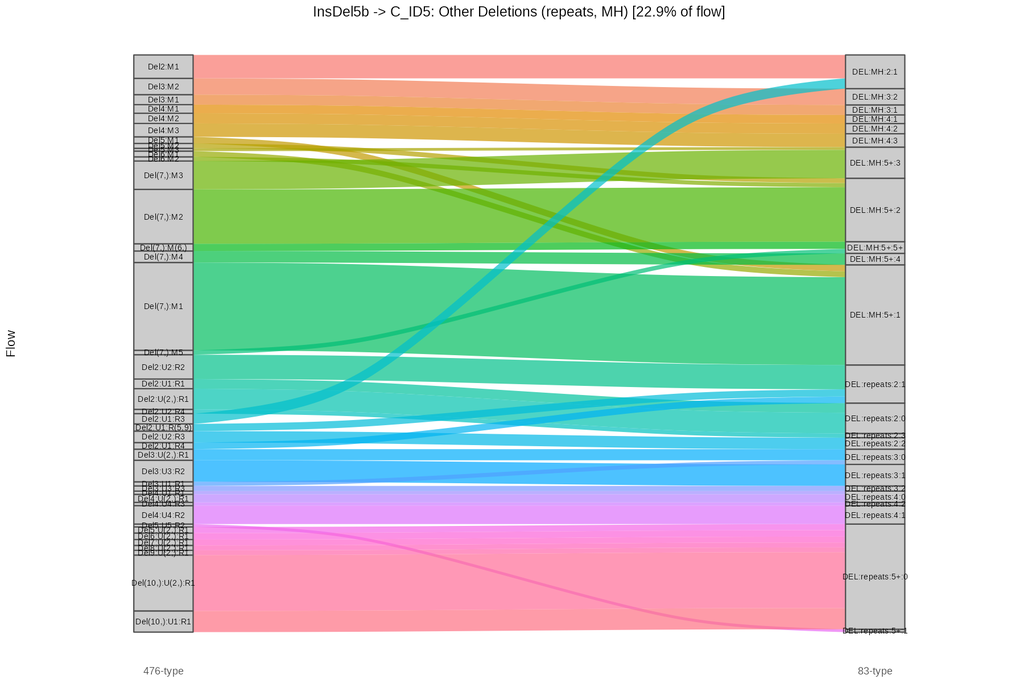

83-type spectrum of the linking tumor SP112290 | cosine similarity to C_ID5: 0.711

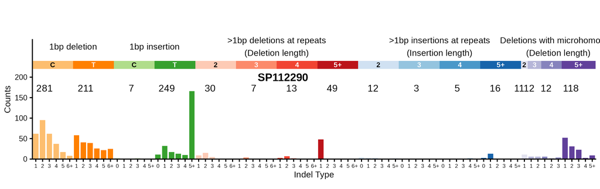

**Click here to see with insertions and deletions of T in long poly-T suppressed**

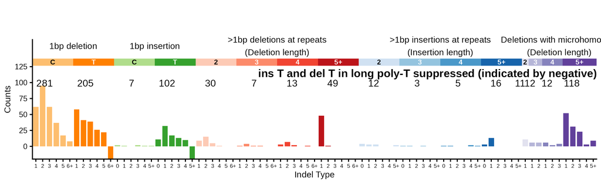

83-type spectrum of best 83-type matching tumor SP102755 | cosine similarity to C_ID5: 0.9948

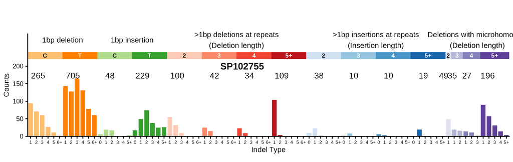

### Similar COSMIC signatures

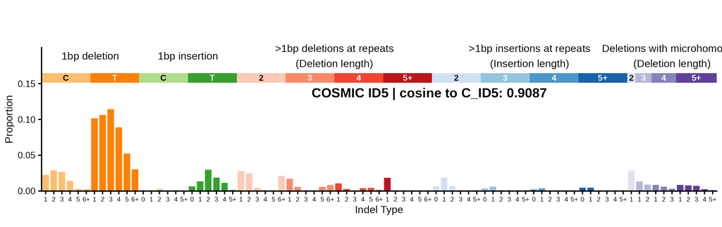